# Krigging Example with Relative Sea Level Rise

Note: This is all on Github @ https://github.com/daveism/RSL-krigging

## First install and load the libraries

```r
#function to install pacakages
is.installed <- function(mypkg){
  is.element(mypkg, installed.packages()[,1])
}


#install if not installed
if (!is.installed("stringr")){ install.packages("sp") }
if (!is.installed("gstat")){ install.packages("gstat") }
if (!is.installed("dplyr")){ install.packages("dplyr") }
if (!is.installed("ggplot2")){ install.packages("ggplot2") }
if (!is.installed("scales")){ install.packages("scales") }
if (!is.installed("magrittr")){ install.packages("magrittr") }
if (!is.installed("maps")){ install.packages("maps") }
if (!is.installed("maptools")){ install.packages("maptools") }
if (!is.installed("plyr")){ install.packages("plyr") }
if (!is.installed("sp")){ install.packages("sp") }
if (!is.installed("rgdal")){ install.packages("rgdal") }
if (!is.installed("rgeos")){ install.packages("rgeos") }
if (!is.installed("raster")){ install.packages("raster") }

#add libraries
suppressPackageStartupMessages({
  library(sp)
  library(gstat)
  library(dplyr)
  library(ggplot2)
  library(scales)
  library(magrittr)
  library(maps)
  library(maptools)
  library(plyr)
  library(rgdal)
  library(rgeos)
  library(raster)
})

 #because scientific notation is not readable by normal people :)
options(scipen = 999)
```

## Load the RSL data I already did some clean up.

```r
intput_data <- "/Users/daveism/GitHub/RSL-krigging/data"

rsl <- read.csv(file.path(intput_data,"rsl.csv"))

glimpse(rsl)
```

```
## Observations: 64
## Variables: 10
## $ region       <int> 1, 2, 2, 3, 3, 3, 4, 4, 4, 4, 5, 5, 5, 5, 5, 6, 6...
## $ holocene_rsl <fctr> -1±??, -0.7±0.1, -0.7±0.1, -0.7±0.5, -0.7±0.5, -...
## $ gps          <fctr> SJNB, BARH, PNB1, BRU1, YMTS, MEGO, ZBW1, WMTS, ...
## $ lat          <dbl> 45.268, 44.395, 44.452, 43.890, 43.799, 43.681, 4...
## $ long         <dbl> -66.050, -68.222, -68.772, -69.947, -70.189, -70....
## $ gps_rate     <fctr> -0.8±0.3, 0.2±0.1, 0.4±0.1, 0.2±0.0, 0.0±0.1, 0....
## $ gps_rate_avg <fctr> -0.8± 0.3, 0.3±0.1, 0.3±0.1, 0.1±0.2, 0.1±0.2, 0...
## $ real_rsl     <dbl> -1.0, -0.7, -0.7, -0.7, -0.7, -0.7, -0.6, -0.6, -...
## $ real_gps     <dbl> -0.8, 0.2, 0.4, 0.2, 0.0, 0.2, -0.6, -1.0, -0.7, ...
## $ real_gps_avg <dbl> -0.8, 0.3, 0.3, 0.1, 0.1, 0.1, -0.7, -0.7, -0.7, ...
```

### set the location of shapefile

```r
shapefiles <- "/Users/daveism/GitHub/RSL-krigging/shapefile"
```

import world Locations Shapefile then subset it for US cities only. We will use this later to zoom into several areas of the country.

```r
places <- readOGR(dsn=shapefiles, layer="places")
places <- subset(places, places$adm0name == 'United States of America')
```

## import states Shapefile. We will use this as a basemap later to zoom into several areas of the country.

```r
states <- readOGR(dsn=shapefiles, layer="states")
states@data$id <- rownames(states@data)
states.points = fortify(states, region="id")
states <- join(states.points, states@data, by="id")
```

## import buffered rsl points shapefile. we will use this to mask the krigging results.

I buffered the rsl points in QGIS.

```r
rslBuffer <- readOGR(dsn=shapefiles, layer="rsl-points-buffer")
```

## setup min and max lat long so we can limit the map later

```r
  max_lat <- as.numeric(max(rsl$lat))
  min_lat <- as.numeric(min(rsl$lat))
  max_long <-as.numeric(max(rsl$long))
  min_long <- as.numeric(min(rsl$long))

  xmin <- max_long
  xmax <- min_long
  ymin <- min_lat
  ymax <- max_lat
  buff <- 15

worldmap = map_data ("world")
wrld <- c(geom_polygon(aes(long,lat,group=group), size = 0.1, colour= "gray50", fill="cornsilk", data=worldmap))

us_base <-  c(geom_polygon(aes(long,lat,group=group), size = 0.1, colour= "gray50", fill="cornsilk", data=states))

  ditch_the_axes <- theme(
  axis.text = element_blank(),
  axis.line = element_blank(),
  axis.ticks = element_blank(),
  panel.border = element_blank(),
  panel.grid = element_blank(),
  axis.title = element_blank()
  )
```

## Scale rsl so we can get a log we will use this later

```r
min_rsl <- abs(min(rsl$real_rsl))
rsl$scaled_rsl <- (rsl$real_rsl + min_rsl) + 1
```

## View RSL

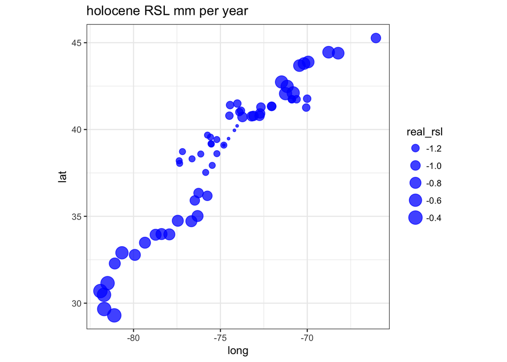

```r
rsl %>% as.data.frame %>%
  ggplot(aes(long, lat)) + geom_point(aes(size=real_rsl), color="blue", alpha=3/4) +
  ggtitle("holocene RSL mm per year") + coord_equal() + theme_bw()
```

## View GPS

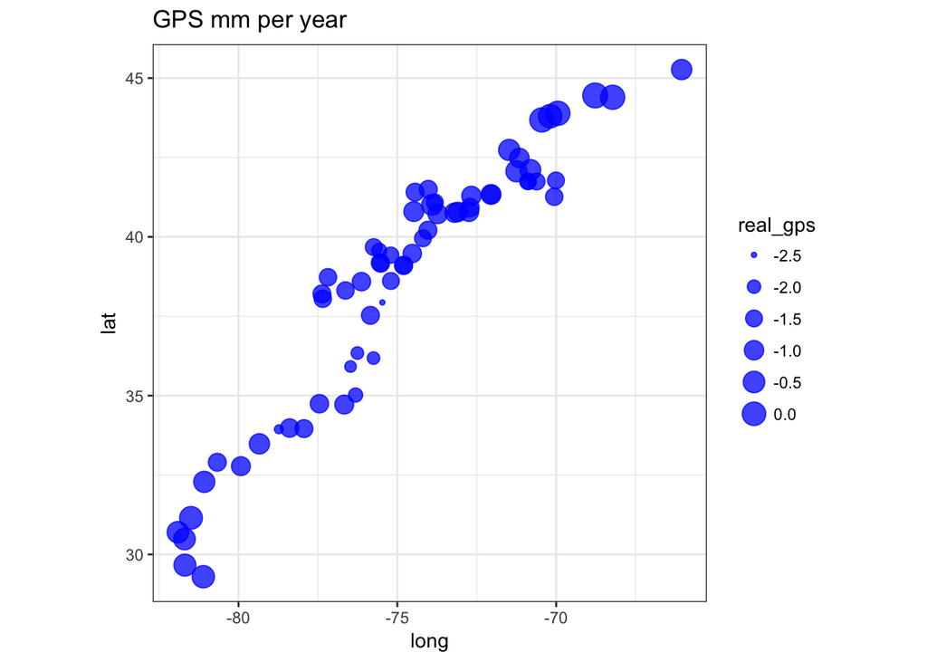

```r
rsl %>% as.data.frame %>%
  ggplot(aes(long, lat)) + geom_point(aes(size=real_gps), color="blue", alpha=3/4) +
  ggtitle("GPS mm per year") + coord_equal() + theme_bw()
```

## View Average GPS

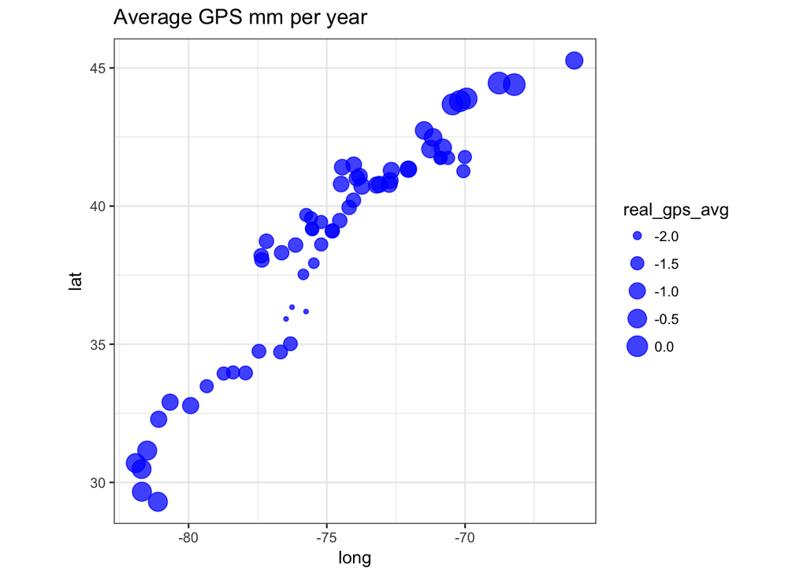

```r
rsl %>% as.data.frame %>%
  ggplot(aes(long, lat)) + geom_point(aes(size=real_gps_avg), color="blue", alpha=3/4) +
  ggtitle("Average GPS mm per year") + coord_equal() + theme_bw()
```

## Map observations with a simple base map

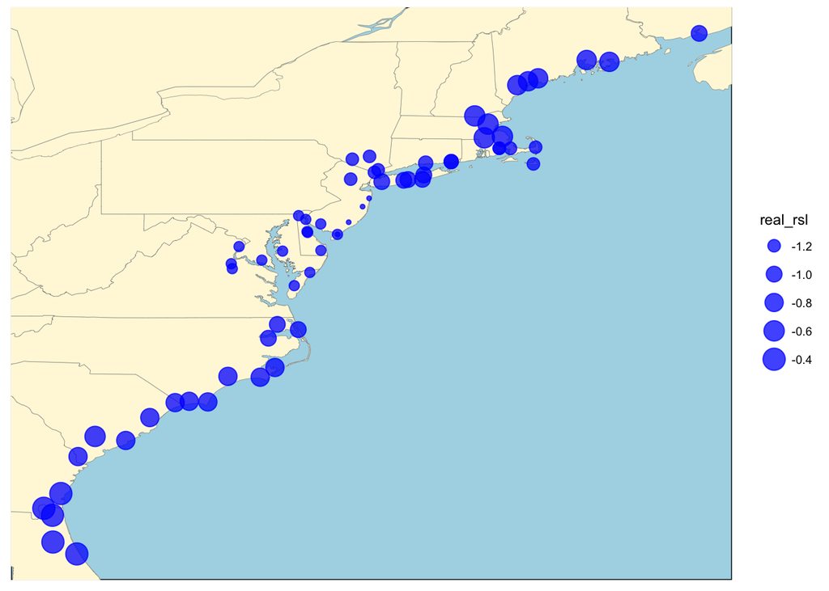

```r
 ggplot() +
    coord_cartesian(xlim = c((xmin),(xmax)), ylim = c((ymin),(ymax))) +
    wrld + us_base  +
   geom_point(data = rsl, aes(x = long, y = lat, size=real_rsl), color="blue", alpha=3/4) +
     theme_minimal(base_size=9) +
   ditch_the_axes +
    theme(panel.background = element_rect(fill='lightblue'))
```

## Make a new dataset so we can convert the RSL data to a sp data frame

```r
rslsp <- rsl
coordinates(rslsp) <- ~ long + lat
bbox(rslsp)
```

```
##          min     max
## long -81.908 -66.050
## lat   29.298  45.268
```

```r
glimpse(rslsp)
```

```
## Formal class 'SpatialPointsDataFrame' [package "sp"] with 5 slots
##   ..@ data       :'data.frame':  64 obs. of  9 variables:
##   .. ..$ region      : int [1:64] 1 2 2 3 3 3 4 4 4 4 ...
##   .. ..$ holocene_rsl: Factor w/ 15 levels "-0.4±0.1","-0.6±0.1",..: 15 4 4 5 5 5 2 2 2 2 ...
##   .. ..$ gps         : Factor w/ 63 levels "ACU5","ACU6",..: 55 4 49 5 60 24 61 58 14 59 ...
##   .. ..$ gps_rate    : Factor w/ 47 levels "-0.2±0.2","-0.3±0.1",..: 11 45 47 44 43 46 6 15 9 6 ...
##   .. ..$ gps_rate_avg: Factor w/ 15 levels "-0.4±0.3","-0.7±0.3",..: 3 15 15 14 14 14 2 2 2 2 ...
##   .. ..$ real_rsl    : num [1:64] -1 -0.7 -0.7 -0.7 -0.7 -0.7 -0.6 -0.6 -0.6 -0.6 ...
##   .. ..$ real_gps    : num [1:64] -0.8 0.2 0.4 0.2 0 0.2 -0.6 -1 -0.7 -0.6 ...
##   .. ..$ real_gps_avg: num [1:64] -0.8 0.3 0.3 0.1 0.1 0.1 -0.7 -0.7 -0.7 -0.7 ...
##   .. ..$ scaled_rsl  : num [1:64] 1.4 1.7 1.7 1.7 1.7 1.7 1.8 1.8 1.8 1.8 ...
##   ..@ coords.nrs : int [1:2] 5 4
##   ..@ coords     : num [1:64, 1:2] -66 -68.2 -68.8 -69.9 -70.2 ...
##   .. ..- attr(*, "dimnames")=List of 2
##   ..@ bbox       : num [1:2, 1:2] -81.9 29.3 -66 45.3
##   .. ..- attr(*, "dimnames")=List of 2
##   ..@ proj4string:Formal class 'CRS' [package "sp"] with 1 slot
```

```r
#write shapefile un comment this if you want the rsl shapefile.  use to create a buffered shapefile for importing
#writeOGR(obj=rslsp, dsn=shapefiles, layer="rslpoints", driver="ESRI Shapefile")
```

## Map RSL using the scaled points

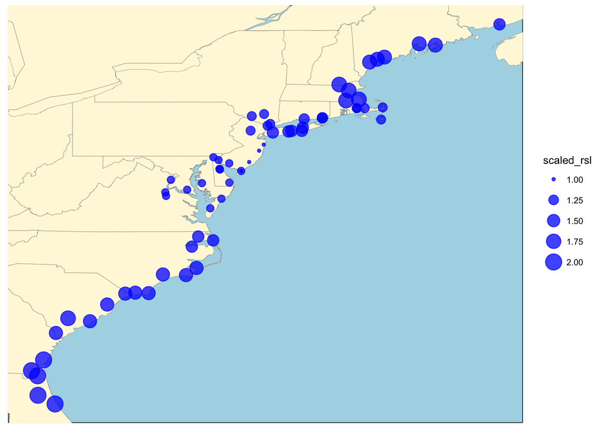

```r
 ggplot() +
    coord_cartesian(xlim = c((xmin),(xmax)), ylim = c((ymin),(ymax))) +
    wrld  +
    us_base +
   geom_point(data = rsl, aes(x = long, y = lat, size=scaled_rsl), color="blue", alpha=3/4) +
     theme_minimal(base_size=9) +
   ditch_the_axes +
    theme(panel.background = element_rect(fill='lightblue'))
```

## Remove Duplicate points? I cannot find them but R complains about them.

```r
#apparently there are duplicated points I cannot find them but this remove them
rslsp <- rslsp [-zerodist(rslsp)[,1],]
```

## Do variogram and fitted variogram?

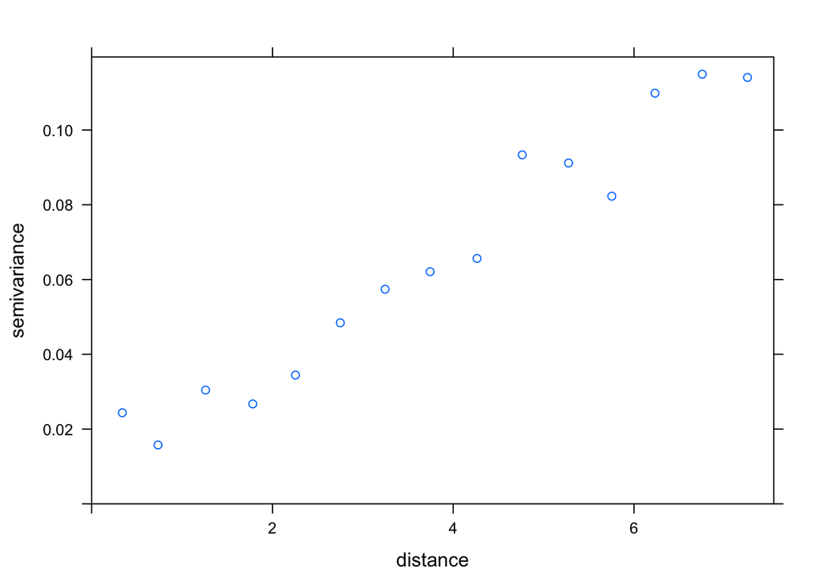

```r
lzn.vgm <- variogram(scaled_rsl~1, rslsp) # calculates sample variogam values
plot(lzn.vgm)
```

## plot the variogram

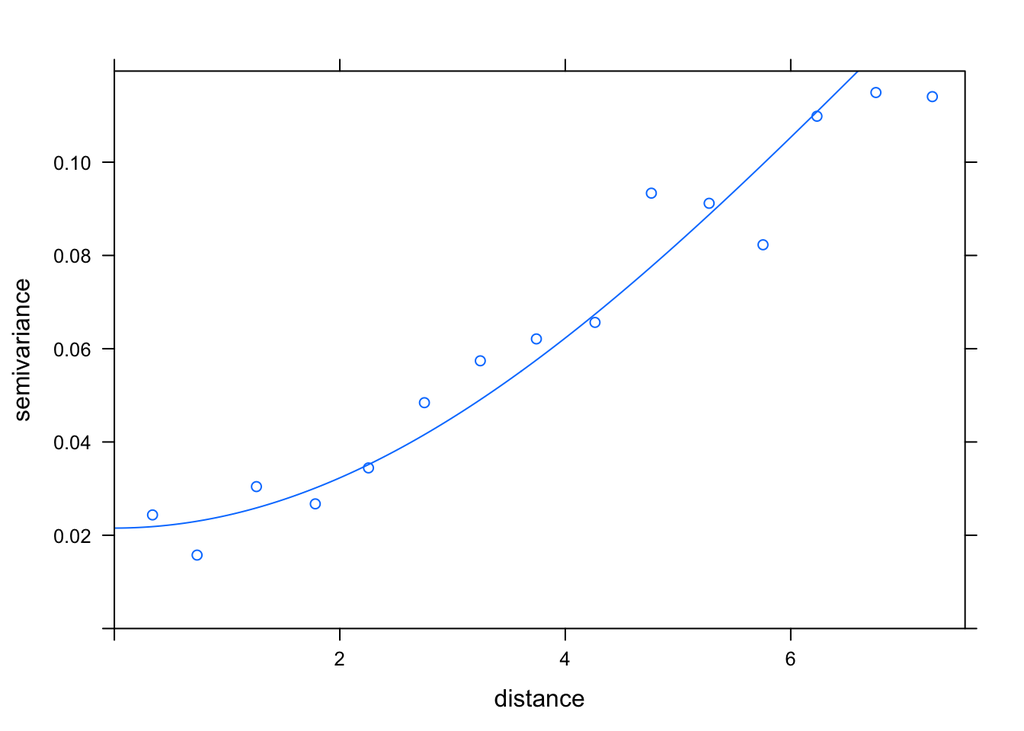

```r
lzn.fit <- fit.variogram(lzn.vgm, model=vgm("Gau")) # fit model
plot(lzn.vgm, lzn.fit)
```

## Create the spatial grid covering the study area here we are setting the number of squares to 7500

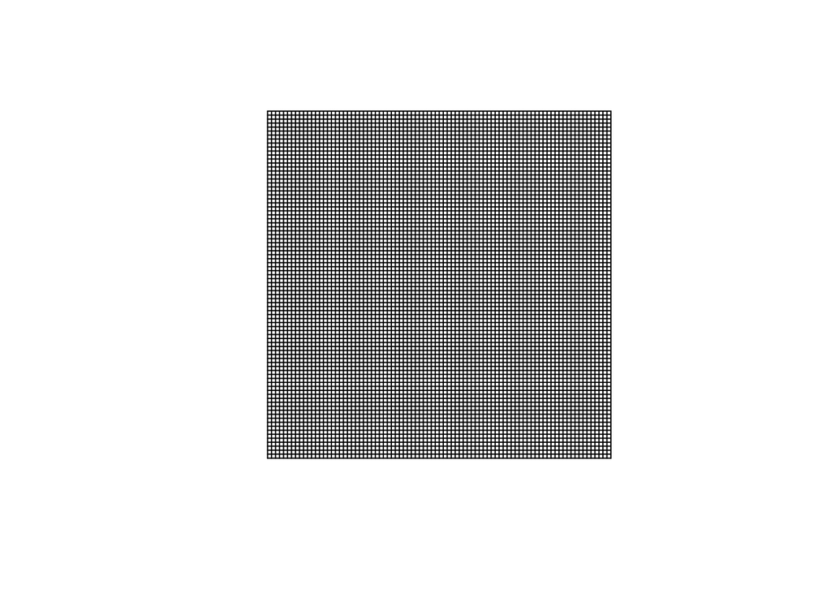

```r
#expand the bounding box so it convers more of the study area
b <- gBuffer(rslsp, width=1)
rslbox <- bbox(b)

grd <- as.data.frame(spsample(rslsp, bb=rslbox , "regular", n=7500))

names(grd) <- c("x", "y")
coordinates(grd) <- c("x", "y")

gridded(grd) <- TRUE  # Create SpatialPixel object
fullgrid(grd) <- TRUE  # Create SpatialGrid object
plot(grd)
```

## Run ordinary krigging on the scaled RSL.

```r
lzn.kriged <- krige(scaled_rsl~1, rslsp , grd, model=lzn.fit)
```

```
## [using ordinary kriging]
```

## Plot the points and the krigging results…

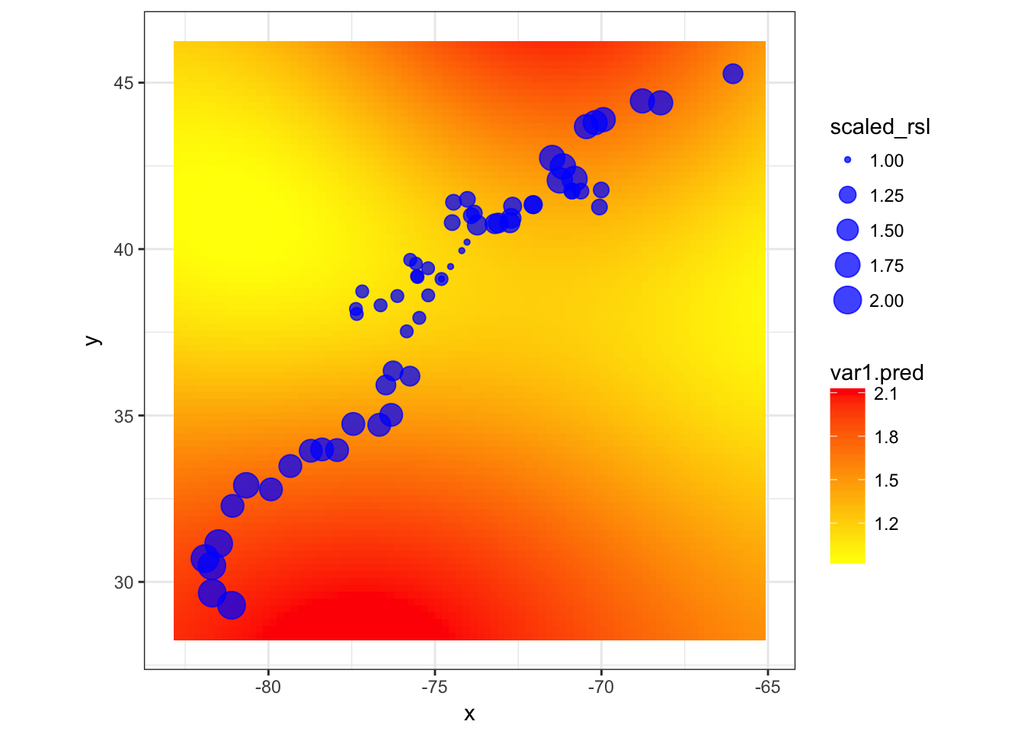

```r
lzn.kriged %>% as.data.frame %>%
  ggplot(aes(x=x, y=y)) + geom_tile(aes(fill=var1.pred)) + coord_equal() +
  scale_fill_gradient(low = "yellow", high="red") +
  geom_point(data = rsl, aes(x = long, y = lat, size=scaled_rsl), color="blue", alpha=3/4) +
  scale_x_continuous(labels=comma) + scale_y_continuous(labels=comma) +
  theme_bw()
```

## Mask the krigged

mask the output with the buffer relative sea level shapefile, this will limit the area we are predicting. Then convert the raster back to sp data frame.

```r
krigged.raster <- raster(lzn.kriged)
krigged.raster.maskedbuff <- mask(krigged.raster, rslBuffer)
lzn.kriged.maskedbuff <- as(krigged.raster.maskedbuff, 'SpatialGridDataFrame')

#write a tiff
writeRaster(krigged.raster, filename="rsl-krigged.tif", format="GTiff", overwrite=TRUE)
```

## Plot the masked krigging

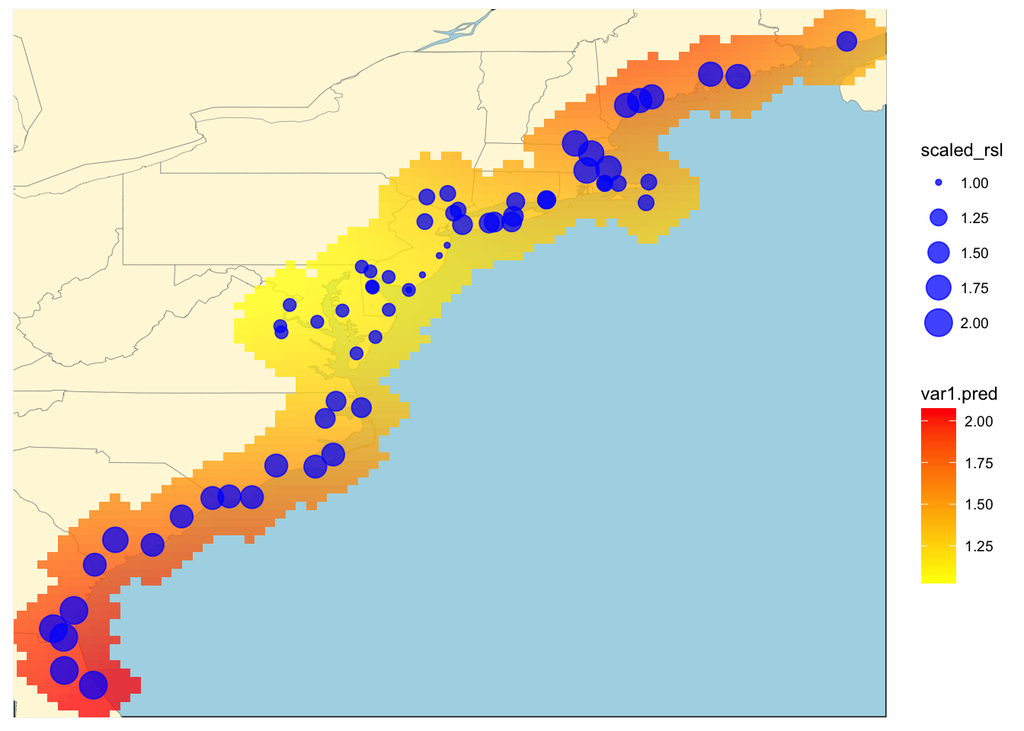

```r
df <- as.data.frame(lzn.kriged.maskedbuff)

  ggplot() +
    wrld  + us_base +
    geom_tile(data=df, aes(x=s1, y=s2, fill=var1.pred), , alpha=0.75) + coord_equal() +
      scale_fill_gradient(low = "yellow", high="red") +
      coord_cartesian(xlim = c((xmin),(xmax)), ylim = c((ymin),(ymax))) +
       geom_point(data = rsl, aes(x = long, y = lat, size=scaled_rsl), color="blue", alpha=3/4) +
     theme_minimal(base_size=9) +
   ditch_the_axes +theme(panel.background = element_rect(fill='lightblue'))
```

## Zoom

Zoom to selected areas to take a peak at what’s happening locally.

```r
plotloc <- function(loc){
  #create extent for Balitmore
  xmin <- loc$longitude - 2.5
  xmax <- loc$longitude + 2.5
  ymin <-  loc$latitude - 1.5
  ymax <-  loc$latitude + 1.5

  df <- as.data.frame(lzn.kriged.maskedbuff)
  map <- ggplot() +
    us_base  +
    geom_tile(data=df, aes(x=s1, y=s2, fill=var1.pred), alpha=0.75) + coord_equal() +
      scale_fill_gradient(low = "yellow", high="red") +
      coord_cartesian(xlim = c((xmin),(xmax)), ylim = c((ymin),(ymax))) +
       geom_point(data = rsl, aes(x = long, y = lat, size=scaled_rsl), color="blue", alpha=3/4) +
     theme_minimal(base_size=9) +
   ditch_the_axes +theme(panel.background = element_rect(fill='lightblue'))

  return(map)
}
```

## Boston, MA

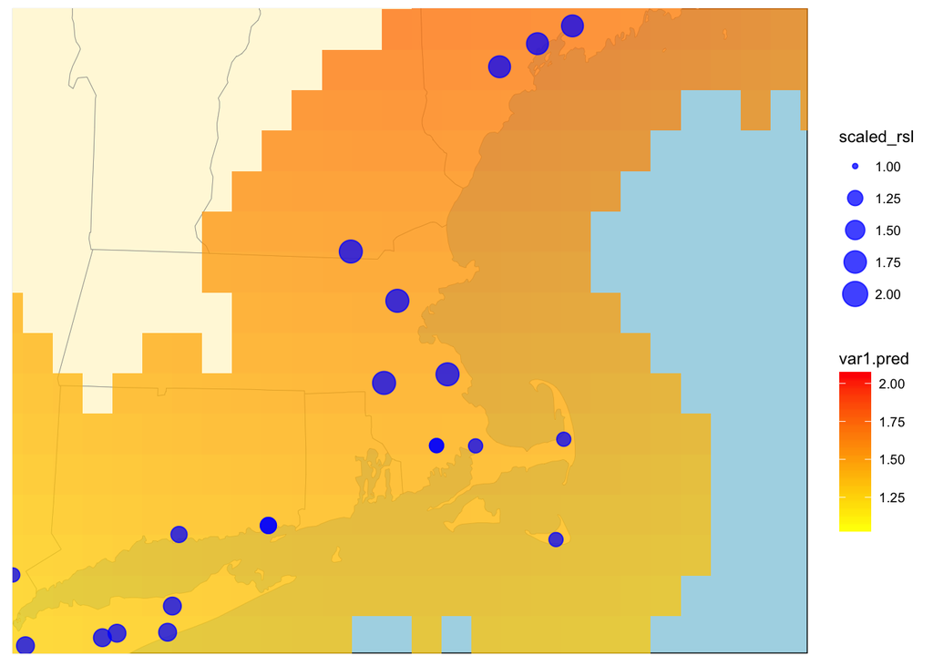

```r
Boston <- subset(places, places$geonameid == 4930956)

BostonMap <- plotloc(Boston)
BostonMap
```

## New York, NY

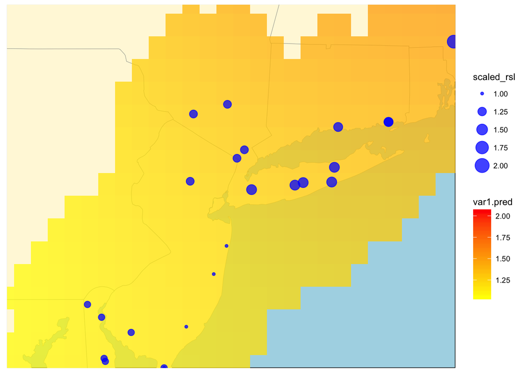

```r
NewYork <- subset(places, places$geonameid == 5128581)

 NewYorkMap <- plotloc(NewYork)
 NewYorkMap
```

## Baltimore, MD

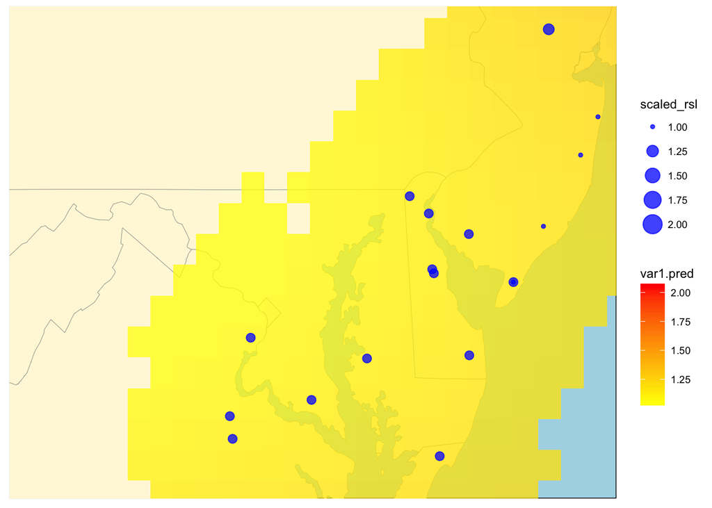

```r
Baltimore <- subset(places, places$geonameid == 4347778)

BaltimoreMap <- plotloc(Baltimore)
BaltimoreMap
```

## Norfolk, VA

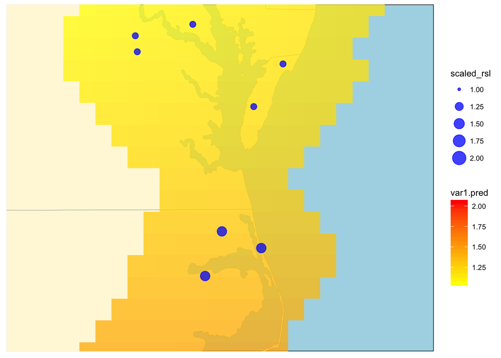

```r
Norfolk <- subset(places, places$geonameid == 4776222)

NorfolkMap <- plotloc(Norfolk)
NorfolkMap
```

## Wilmington, NC

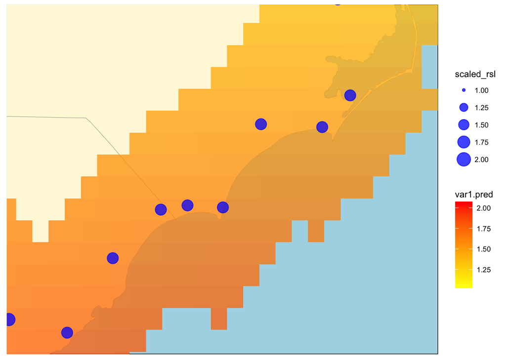

```r
Wilmington <- subset(places, places$geonameid == 4499379)

WilmingtonMap <- plotloc(Wilmington)
WilmingtonMap
```

## Charleston, SC

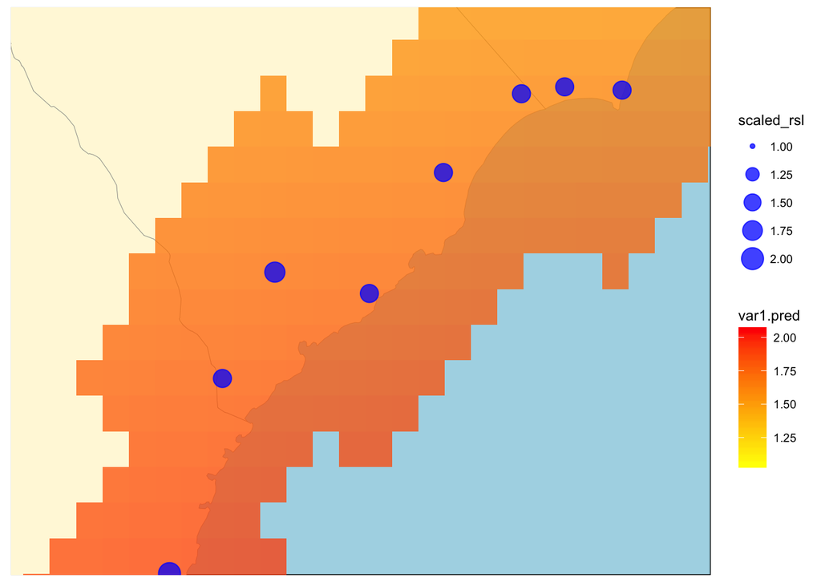

```r
Charleston <- subset(places, places$geonameid == 4574324)

CharlestonMap <- plotloc(Charleston)
CharlestonMap
```

## Savannah, SC

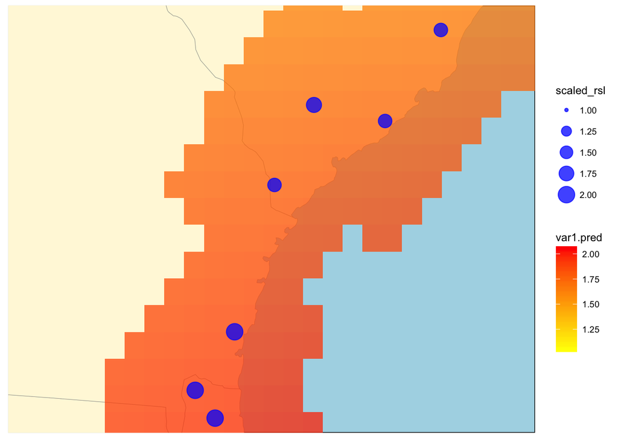

```r
Savannah <- subset(places, places$geonameid == 4221552)


SavannahMap <- plotloc(Savannah)
SavannahMap
```

## Jacksonville, FL

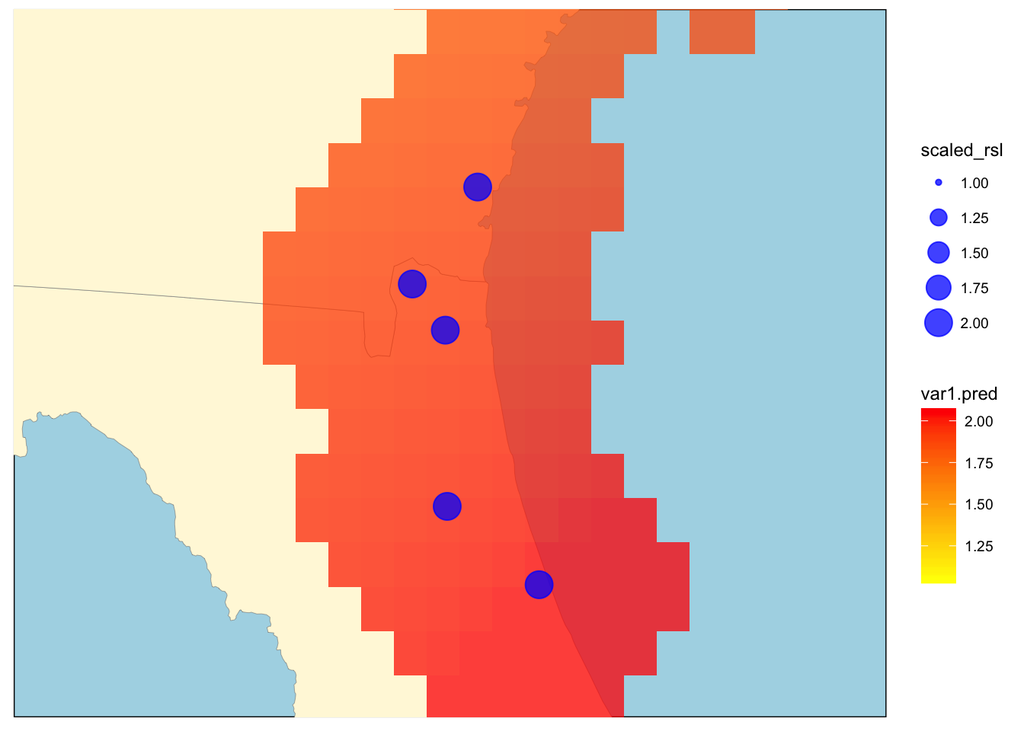

```r
Jacksonville <- subset(places, places$geonameid == 4160021)


JacksonvilleMap <- plotloc(Jacksonville)
JacksonvilleMap
```